# 03-rmd-lm-tables-inline-eqn

2017/06/27

# Tasks

- fit a linear model of Ozone ~ Temp + Wind + Solar.R
  - (hint: use `lm`)
- Make a table of the coefficients from the linear model
  - (hint: use `coef` and `knitr::kable`)
- Make some inline code chunks that describe the single values of the R-squared or a coefficient
- Make an equation describing the relationship

# Introduction

This is a simple analysis of the New York Air Quality Measurements using the R statistical programming language. As stated in the helpfile `?airquality`, this dataset contains:

> Daily air quality measurements in New York, May to September 1973.

And the dataset is sourced from:

> … the New York State Department of Conservation (ozone data) and the National Weather Service (meteorological data).

It contains the following variables

- Ozone: Mean ozone in parts per billion from 1300 to 1500 hours at Roosevelt Island.
- Solar.R: Solar radiation in Langleys in the frequency band 4000–7700 Angstroms from 0800 to 1200 hours at Central Park.
- Wind: Average wind speed in miles per hour at 0700 and 1000 hours at LaGuardia Airport.
- Temp: Maximum daily temperature in degrees Fahrenheit at La Guardia Airport.
- Month: Month (1–12)
- Day: Day of month (1–31)

# Results

We can see that there is an interesting relationship between ozone and solar radiation in figure 1 below, plotted using ggplot2.

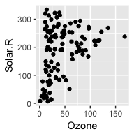

```r
library(ggplot2)
ggplot(airquality,
       aes(x = Ozone,
           y = Solar.R)) +
  geom_point()
```

We can also see that there is an interesting relationship between Ozone and temperature.

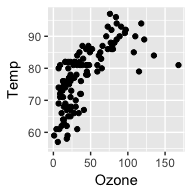

- fit a linear model of Ozone ~ Temp + Wind + Solar.R
  - (hint: use `lm`)

```r
lm_fit <- lm(Ozone ~ Temp + Wind + Solar.R,
             airquality)

lm_fit_coef <- coef(lm_fit)

lm_fit_coef
```

```
##  (Intercept)         Temp         Wind      Solar.R
## -64.34207893   1.65209291  -3.33359131   0.05982059
```

- Make a table of the coefficients from the linear model
  - (hint: use `coef` and `knitr::kable`)

```r
library(knitr)

kable(lm_fit_coef)
```

| (Intercept) | -64.3420789 |
| --- | --- |
| Temp | 1.6520929 |
| Wind | -3.3335913 |
| Solar.R | 0.0598206 |

```r
kable(as.data.frame(lm_fit_coef))
```

|  | lm_fit_coef |
| --- | --- |
| (Intercept) | -64.3420789 |
| Temp | 1.6520929 |
| Wind | -3.3335913 |
| Solar.R | 0.0598206 |

- Make some inline code chunks that describe the single values of the R-squared or a coefficient

```r
lm_fit_coef[1]
```

```
## (Intercept)
##   -64.34208
```

We see that the intercept of the model is at -64.3420789

- Make an equation describing the relationship